# Paper:

## A zonal wave 3 index for the Southern Hemisphere - Marilyn Raphael

[link](http://onlinelibrary.wiley.com/doi/10.1029/2004GL020365/full)

### Descripción y replicación

Describe características de la onda 3 que son consistentes con lo que se ve en la regresión de QS3 con geopotencial en 300hPa de mis figuras (¡yey!). Altas a sotavento de los continentes y un corrimiento de fase entre otoño e invierno que se revierte en primavera.

Utilizando la ubicación media de estas altas, calcula un índice a partir de la altura geopotencial en 500hPa. El índice es

$$I_i = \frac{X_{3m} - \bar{X}_{3m}}{\sigma_{3m}} \\
I = \mathrm{mean}(I_i)$$

Donde $X_{3m}$ es la media trimensual de la variable, $\bar{X}_{3m}$ es la media climatológica de la media trimensual y $\sigma_{3m}$ es el desvío estandar de la media trimensual. Se calcula el índice en 3 puntos $i$ (50°E, 166°E y 76°W, todos en 49°S) y el índice de onda 3 es la media de los 3 sub-índices.

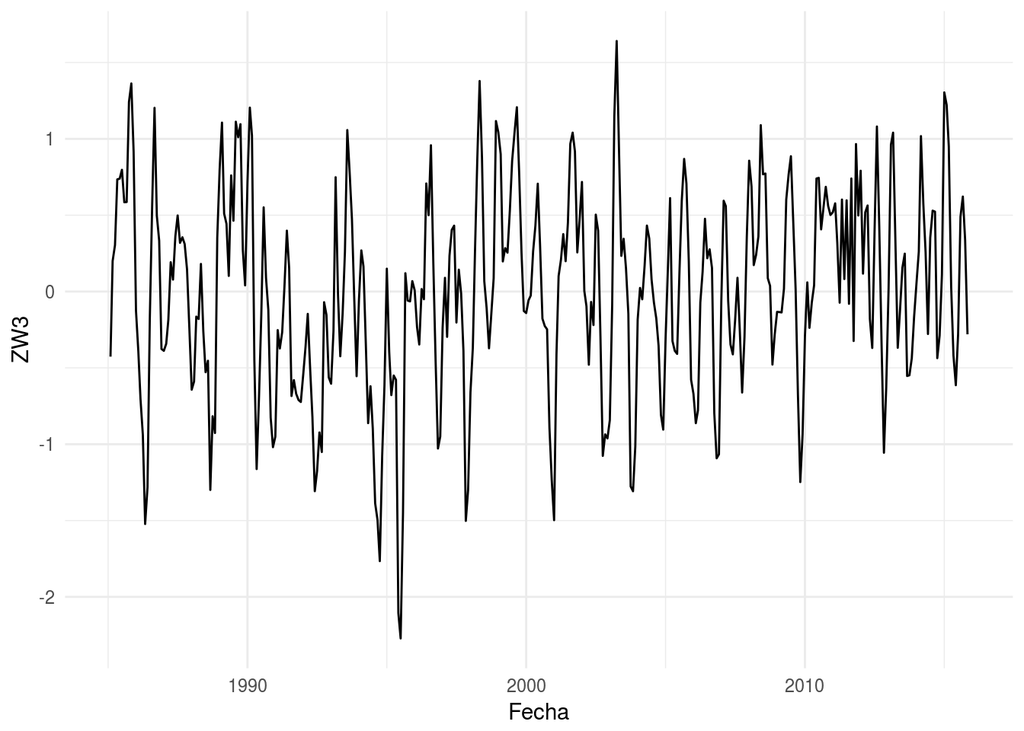

```r
load("NCEP/todo_ncep.rda")
invisible({
zw <- ncep[lat %~% -49 & lev == 500]
zw[, agh := anom(gh), by = month]
zw <- zw[lon %~% 50 | lon %~% 166 | lon %~% 289]
zw <- zw[, .(agh = zoo::rollmean(agh, k = 3, fill = NA), time = time), by = .(lon)]
zw[, I := as.numeric(scale(agh)), by = .(lon)]
zw3 <- zw[, .(I = mean(I)), by = .(time)]
})

ggplot(zw3, aes(as.Date(time), I)) + geom_line() +
  theme_elio +
  ylab("ZW3") + xlab("Fecha") +
  scale_x_date(date_labels = "%Y")
```

Los resultados no son idéntidos –debido a el uso de un período más corto– pero sí comparables. En particular, se ve muy bien la fase negativa en la midad de los 90.

El paper muestra un ciclo anual. Mi replicación consigue uno con una forma similar

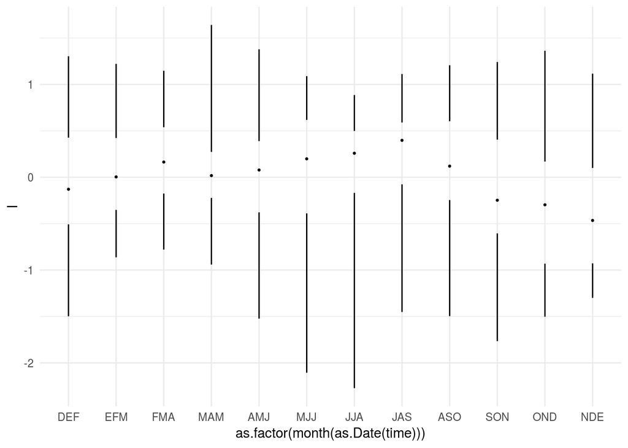

```r
ggplot(zw3, aes(as.factor(month(as.Date(time))), I)) +
  geom_tufteboxplot() +
  scale_x_discrete(labels = c("DEF", "EFM", "FMA", "MAM", "AMJ", "MJJ", "JJA", "JAS", "ASO", "SON", "OND", "NDE")) + theme_elio
```

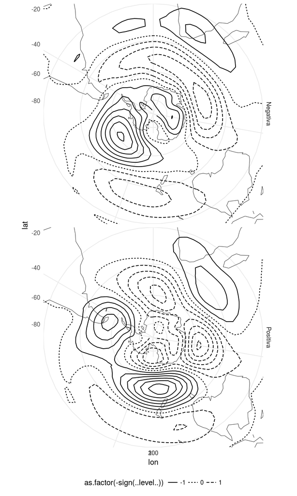

```r
invisible({
ncep <- ncep[zw3, on = "time"]
comp <- ncep[lev == 500]
comp[, agh := anom(gh), by = .(lat, month)]
comp[, Fase := ifelse(I >= 1, "Positiva", ifelse(I <= -1, "Negativa", "Neutra"))]
comp <- comp[, .(agh = mean(agh)), by = .(lon, lat, Fase)]
})
ggplot(rep_lon(comp[Fase %in% c("Positiva", "Negativa")]), aes(lon, lat)) +
  geom_contour(aes(z = agh, linetype = as.factor(-sign(..level..))), binwidth = 20, color = "black") +
  facet_grid(Fase~.) + world3 +
  coord_map("stereographic", orientation = c(-90,0, 0), ylim = c(-90, -20)) +
  theme_elio
```

### Comentarios

Está bueno tener el índice, pero ¿por qué hacer uno en base a mediciones en puntos específicos? Especialmente considerando que no está usando mediciones de estaciones. En el paper la autora comenta que el corrimiento en la fase durante el invierno modifica el índice incluso aunque la actividad de la onda sea igual. ¿Por qué no calcular la magnitud de la onda 3 y seacabó? No entiendo bien.

Tampoco entiendo por qué usar 500hPa cuando en mi análisis anterior se ve que el máximo de la onda se da en ~300hPa

Pero bueno, ¿qué tan bien coincide el índice de Raphael con la amplitud de la QS3 alrededor de 300 hpa?

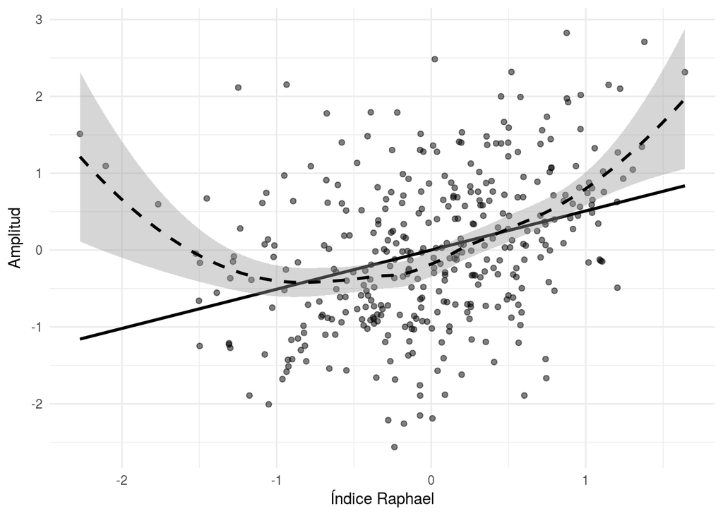

```r
load("NCEP/ncep_r3.rda")

invisible({
ncep_r3[, agh := anom(gh), by = .(lat, lev, month)]
qs3 <- ncep_r3[, qs_fit(agh, n = 3), by = .(lat, lev, time)]
qs3[, month := as.numeric(stringi::stri_sub(time, 6, 7))]
qs3[, month := factor(month, levels = c(12, 1:11), ordered = T)]
qs3[, year := as.numeric(stringi::stri_sub(time, 1, 4))]


qs3_mean <- qs3[, .(Mean_Ampl = mean(Amplitud),
                    Fase = mean(Fase)),
              by = .(time)]


indices <- zw3[qs3_mean[, .(time, Mean_Ampl, Fase)], on = "time"]
setnames(indices, c("I", "Mean_Ampl"), c("Raphael", "Amplitud"))
indices[, Amplitud := zoo::rollmean(Amplitud, 3, fill = NA)]
indices[, Amplitud := as.numeric(scale(Amplitud)), by = month(time)]
indices[, Fase := zoo::rollmean(Fase, 3, fill = NA)*180/pi]
indices[, Fase := Fase - mean(Fase), by = month(time)]

})
ggplot(indices, aes(Raphael, Amplitud)) +
  geom_point(alpha = 0.5) +
  geom_smooth(method = "lm", color = "black", se = F) +
  geom_smooth(color = "black",  linetype = 2) +
  ylab("Amplitud") + xlab("Índice Raphael") +
  theme_elio
```

Respuesta: para el ogt. La correlación es de 0.3401266, lo cual no parece muy bueno. (Aclaración: la amplitud originalmente es mensual y no está estandarizada; para esta comparación hice una media móvil de 3 meses y luego estandaricé según la media y el desvío estándar de cada trimes). Es más, la línea a rayas es la relación a partir de un suavizado local donde hay claros indicios de una relación no lineal.

También se puede buscar la relación entre el índice de Raphael y la fase de la onda 3.

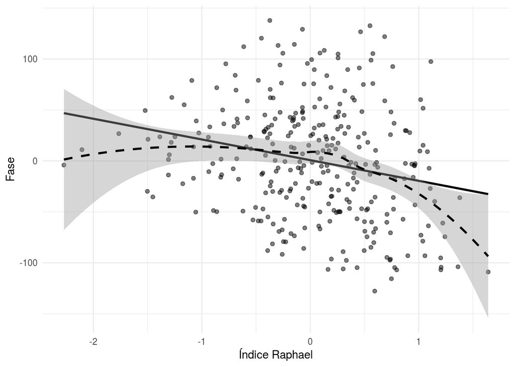

```r
ggplot(indices, aes(Raphael, Fase)) +
  geom_point(alpha = 0.5) +
  geom_smooth(method = "lm", color = "black", se = F) +
  geom_smooth(color = "black",  linetype = 2) +
  ylab("Fase") + xlab("Índice Raphael") +
  theme_elio
```

Se ve que hay una relación, lo cual es un problema ya que quiere decir que no sólo está capturando la actividad de la onda sino también su posición. ¿Es un problema? Quizás para el uso operativo sea una ventaja si es que con un sólo número se busca sumarizar ambas variables de una forma consistente con sus efectos, pero para la investigación básica, a mí me parece que es mejor que no haya contaminación entre variables.

Podemos ver cómo interaccionan las 4 variables

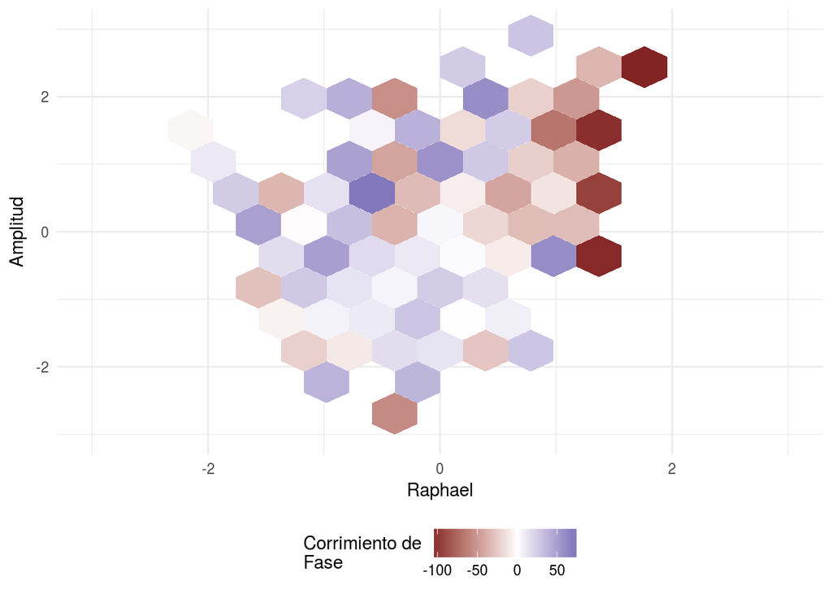

```r
ggplot(indices, aes(Raphael, Amplitud)) +
  stat_summary_hex(aes(z = Fase), bins = 10) +
  scale_fill_gradient2(name = "Corrimiento de \nFase") +
  coord_cartesian(xlim = c(-3, 3), ylim = c(-3, 3)) +
  theme_elio
```

Mirando el corrimiento de la fase con respecto a su media trimensual en cada región del espacio muetral se ve que cuando el índice y la amplitud están en una etapa muy positiva, la fase suele ser negativa y viceversa.

Pero si vemos la serie temporal, taaan mal no está. Se puede ver que hay años donde la amplitud y el índice se siguen más o menos bien, aunque en otros está muy mal. Cerca de 1990, por ejemplo, ambos concuerdan; mientras que para 1995, el importante evento de índice negativo en el índice de Raphael ¡aparece como un evento positivo en la amplitud de la onda!

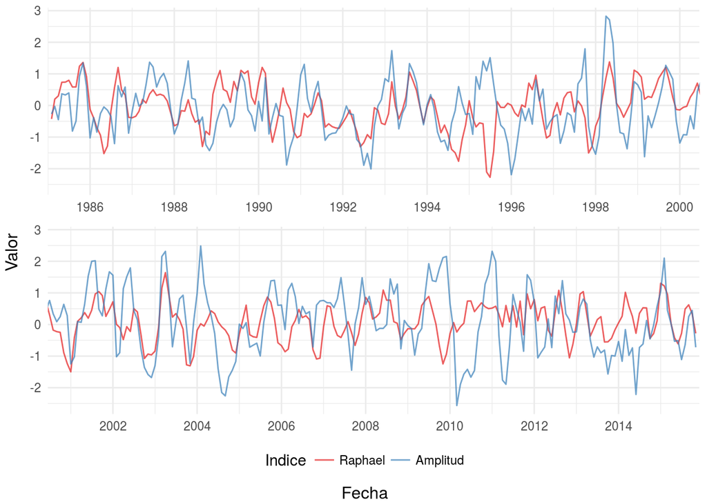

```r
g <- ggplot(melt(indices[, .(time, Raphael, Amplitud)],
            id.vars = "time", variable.name = "Indice", value.name = "valor"),
       aes(as.Date(time), valor, color = Indice)) +
  geom_line(alpha = 0.7) +
  scale_color_brewer(palette = "Set1") +
  ylab("Valor del índice") + xlab("Fecha") +
  scale_x_date(expand = c(0, 1), date_breaks  = "2 years", date_labels = "%Y") +
  theme_elio

panel_timeseries(g, as.Date(indices$time), n = 2, xlab = "Fecha", ylab = "Valor")
```

Cabe una alcaración imporante que quizás explique parte de la diferencia. La amplitud es, antes de ser estandarizada, intrínsecamente positiva mientras que el índice de Raphael, no. En el caso de que la onda 3 tenga una amplitud grande pero que la fase esté corrida 180°, La amplitud sería muy positiva mientras que el índice de Raphael daría negativo.

## The influence of atmospheric zonal wave three on Antarctic sea ice variability - Marilyn Raphael

### Descripción y replicación

En este paper agarra el índice que desarrolló anteriormente y lo usa para caracterizar el impacto de la onda 3 en el hielo marítimo. Curisoamente, comenta que en el paper anterior había un error en los datos que exageraba los valores negativos y el evento negativo de medidados de los 90 se reduce mucho una vez corregido.

Dada la estructura de cuñas y vaguadas asociada a la QS3, los resultados no son sorprendentes. Las regiones asociadas con viento meridional del norte muestran menor concentración de hielo y viceversa. Esto se apoya también en la relación de la temperatura del aire y el flujo de calor con el índice de onda 3 (nuevamente, alta tempertura y flujo hacia el océano donde hay viento del norte y viceversa).

Estas dos últimas variables tienen que ver con procesos termodinámicos, pero estaría bueno también complementarlo con el flujo de la banquisa de hielo para tener los procesos dinámicos. Para eso, tomé los datos de flujo de hielo marítimo del NSIDC. Los datos están en un sistema de coordenadas molesto, puestos en una grilla regular a partir de una proyección estereográfica (no tan malo, graficar es más rápido porque no hay que proyectar nada) y con la velocidad vertical y horizontal con respecto a esa grilla (MUY molesto, porque hay que transformarla a velocidad meridional y zonal).

(cita: Tschudi, M., C. Fowler, J. Maslanik, J. S. Stewart, and W. Meier. 2016. Polar Pathfinder Daily 25 km EASE-Grid Sea Ice Motion Vectors. Version 3. [indicate subset used]. Boulder, Colorado USA: National Snow and Ice Data Center. doi: http://dx.doi.org/10.5067/O57VAIT2AYYY. )

Entonces, hago la correlación de la velocidad meridional de la calota de hielo con el índice de Raphael y con la Amplitud de la onda 3.

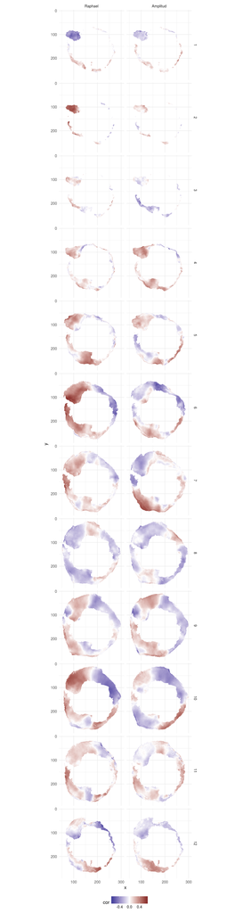

```r
load("NCEP/iceflow.rda")
setkey(iceflow, x, y)
# iceflow[, time := as.Date(paste(año, mes, "01", sep = "-"))]

# calculo el flujo meridional
iceflow[, V := sqrt(v^2 + u^2)]
iceflow[, angle := atan2(v, u)]
iceflow[, real_angle := angle - lon*pi/180]
iceflow[, real_v := sin(real_angle)*V]

indices.l <- melt(indices[, `:=`(mes = month(time), año = year(time))],
                  id.vars = c("mes", "año"), measure.vars = c("Raphael", "Amplitud"),
                  variable.name = "indice", value.name = "valor")


ice.indice <- merge(iceflow[, .(x, y, mes, año, real_v)],
                    indices.l,
                    by = c("mes", "año"), allow.cartesian = T)

ice.cor <- ice.indice[!is.na(valor),
                      .(cor = cor(valor, real_v),
                          n = .N),
                      by = .(x, y, indice, mes)]


ggplot(ice.cor[n > 20], aes(x, y)) +
  geom_raster(aes(fill = cor), interpolate = T) +
  scale_y_reverse() +
  facet_grid(mes~indice) +
  scale_fill_gradient2(low = muted("blue"), high = muted("red")) +
  coord_fixed() +
  theme_elio
```

En algunos meses dan muy similares pero en otros muy distintos. Agosto, septiembre y octubre son casi idénticos, mientras que en julio el patrón en el mar de Weddell ¡es opuesto!

Valores positivos indican movimiento de la calota hacia el norte, lo cual implica generlamente mayor extensión de hielo.

Si nos concentramos en el trimestre abril, mayo, junio (como el paper), tenemos esto:

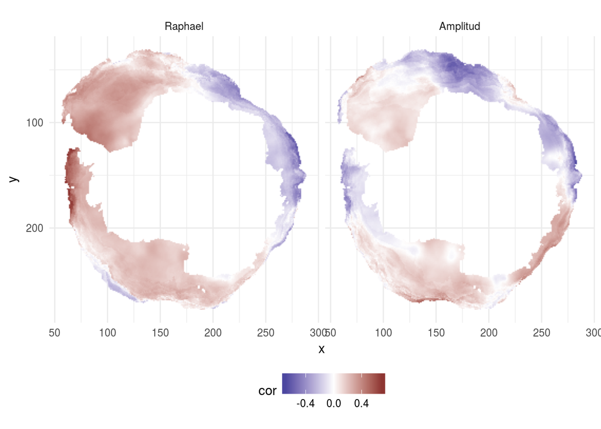

```r
ice.cor <- ice.indice[!is.na(valor) & mes %in% 4:6,
                      .(cor = cor(valor, real_v),
                          n = .N),
                      by = .(x, y, indice)]


ggplot(ice.cor[n > 20], aes(x, y)) +
  geom_raster(aes(fill = cor), interpolate = T) +
  scale_y_reverse() +
  facet_grid(~indice) +
  scale_fill_gradient2(low = muted("blue"), high = muted("red")) +
  coord_fixed() +
  theme_elio
```

La correlación con el índice de Raphael no muestra lo esperado. El patrón de vientos de la onda 3 es de flujo hacia el sur en el Mar de Bellingshausen, pero allí se tiene correlaciones postivas muy grades. La amplitud de la onda 3, por su parte, tiene un patrón más consitente con lo esperado, con flujos de hielo hacia el sur en el mar de Bellinghausen y hacia el norte en el mar de Ross. En Anrártida Oriental ambos patrones son similares y consistentes con lo esperado.

### Comentarios

Los resultados del paper son relativamente predecibles pero interesantes. En particular, es curioso que los patrones de concentración de hielo son similares (en Antártida Orienal, al menos) a las [tendencias observadas](https://nsidc.org/cryosphere/icelights/2012/01/sea-ice-down-under-antarctic-ice-and-climate) (aumento de la extensión en el Mar de Weddell, disminución en el Mar de Bellingshausen y aumento en el Mar de Ross)